# Code: Tables & Figures

## **Main Text Tables and Figures**

Load packages.

```r
library(tidyverse)
library(haven)
library(xlsx)
library(flextable)
library(gtsummary)
library(corrplot)
library(cowplot)
```

### Table 1

Distribution of sociodemographic characteristics, dietary patterns, and housing characteristics, in the analytic subset of the Atlanta African American Maternal-Child Cohort (ATL AA)

#### Analytic sample

##### Demographics/Home

```r
# Select variables
table_1 <- final_adj %>% dplyr::select(`Maternal Age`, `Maternal Education`, `Marital Status`, `Income to Poverty Ratio`, `Insurance Type`, `Prenatal Site`, `Parity`, `Maternal BMI`, `Substance Use`, `Home Age`, `Home Type`, `Couch Age`, `Vacuums`, `Cleaning Frequency`)

# Table
table_1 <- table_1 %>%
  tbl_summary(statistic = all_continuous() ~ "{mean} ({sd})", digits = all_continuous() ~ 2, missing_text = "(Missing)") %>% modify_caption("Table 1: Distribution of sociodemographic characteristics and housing characteristics, in the analytic subset of the Atlanta African American Maternal-Child Cohort (ATL AA)")

table_1
```

Table 1: Distribution of sociodemographic characteristics and housing characteristics, in the analytic subset of the Atlanta African American Maternal-Child Cohort (ATL AA)

| **Characteristic** | **N = 54**<sup>1</sup> |
| --- | --- |
| Maternal Age | 25.85 (4.45) |
| Maternal Education |  |
| < some college | 34 (63%) |
| >= College degree | 20 (37%) |
| Marital Status |  |
| Married/Living with a partner | 23 (43%) |
| Single | 31 (57%) |
| Income to Poverty Ratio |  |
| <100% | 27 (50%) |
| 100% - 199% | 16 (30%) |
| >200% | 11 (20%) |
| Insurance Type |  |
| Medicaid | 44 (81%) |
| Private | 10 (19%) |
| Prenatal Site |  |
| Grady | 37 (69%) |
| Emory | 17 (31%) |
| Parity |  |
| No prior births | 19 (35%) |
| 1 or more prior births | 35 (65%) |
| Maternal BMI |  |
| Underweight or normal | 19 (35%) |
| Overweight | 15 (28%) |
| Obese | 20 (37%) |
| Substance Use | 24 (44%) |
| Home Age |  |
| < 10 years old | 16 (34%) |
| > 10 years old | 31 (66%) |
| (Missing) | 7 |
| Home Type |  |
| Single Family Home | 25 (46%) |
| Multi Family Home | 11 (20%) |
| Apartment | 18 (33%) |
| Couch Age |  |
| < 5 years old | 27 (59%) |
| > 5 years old | 19 (41%) |
| (Missing) | 8 |
| Vacuums | 39 (74%) |
| (Missing) | 1 |
| Cleaning Frequency |  |
| Daily or more often | 20 (37%) |
| A few times a week | 23 (43%) |
| <= Once every couple of weeks | 11 (20%) |

<sup>1</sup> Mean (SD); n (%)

#### Diet

```r
# Select variables
table_11 <- final_adj_diet %>% dplyr::select(`Red Meat`,Milk, Cheese, Yogurt)

# Table
table_11 <- table_11 %>%
  tbl_summary(statistic = all_continuous() ~ "{mean} ({sd})", digits = all_continuous() ~ 2, missing_text = "(Missing)") %>% modify_caption("Table 1: Distribution of dietary patterns in the analytic subset of the Atlanta African American Maternal-Child Cohort (ATL AA)")

table_11
```

Table 1: Distribution of dietary patterns in the analytic subset of the Atlanta African American Maternal-Child Cohort (ATL AA)

| **Characteristic** | **N = 54**<sup>1</sup> |
| --- | --- |
| Red Meat |  |
| < 2-3 times per month | 15 (50%) |
| >= 2-3 times per month | 15 (50%) |
| (Missing) | 24 |
| Milk |  |
| < Once a week | 17 (55%) |
| >= Once a week | 14 (45%) |
| (Missing) | 23 |
| Cheese |  |
| < Once a week | 15 (48%) |
| >= Once a week | 16 (52%) |
| (Missing) | 23 |
| Yogurt |  |
| < Once a week | 26 (84%) |
| >= Once a week | 5 (16%) |
| (Missing) | 23 |

<sup>1</sup> n (%)

#### Full cohort

##### Demographics/Home

```r
# Select variables
table_1_2 <- atl2 %>% dplyr::select(`Maternal Age`, `Maternal Education`, `Marital Status`, `Income to Poverty Ratio`, `Insurance Type`, `Prenatal Site`, `Parity`, `Maternal BMI`, `Substance Use`)

# Table
table_1_2 <- table_1_2 %>%
  tbl_summary(statistic = all_continuous() ~ "{mean} ({sd})", digits = all_continuous() ~ 2, missing_text = "(Missing)") %>% modify_caption("Table 1: Distribution of sociodemographic characteristics and housing characteristics, in the analytic subset of the Atlanta African American Maternal-Child Cohort (ATL AA)")
table_1_2
```

Table 1: Distribution of sociodemographic characteristics and housing characteristics, in the analytic subset of the Atlanta African American Maternal-Child Cohort (ATL AA)

| **Characteristic** | **N = 258**<sup>1</sup> |
| --- | --- |
| Maternal Age | 26.41 (5.26) |
| Maternal Education |  |
| < some college | 200 (78%) |
| >= College degree | 58 (22%) |
| Marital Status |  |
| Married/Living with a partner | 123 (48%) |
| Single | 135 (52%) |
| Income to Poverty Ratio |  |
| <100% | 104 (43%) |
| 100% - 199% | 98 (40%) |
| >200% | 42 (17%) |
| (Missing) | 14 |
| Insurance Type |  |
| Medicaid | 212 (82%) |
| Private | 46 (18%) |
| Prenatal Site |  |
| Emory | 108 (42%) |
| Grady | 150 (58%) |
| Parity |  |
| 1 or more prior births | 151 (59%) |
| No prior births | 107 (41%) |
| Maternal BMI |  |
| Underweight or normal | 84 (33%) |
| Overweight | 63 (24%) |
| Obese | 111 (43%) |
| Substance Use | 75 (30%) |
| (Missing) | 4 |

<sup>1</sup> Mean (SD); n (%)

```r
table_1_2 <- atl2 %>% dplyr::select(`Home Age`, `Home Type`, `Couch Age`, `Vacuums`, `Cleaning Frequency`)

table_1_2 <- table_1_2 %>%
  tbl_summary(statistic = all_continuous() ~ "{mean} ({sd})", digits = all_continuous() ~ 2, missing_text = "(Missing)") %>% modify_caption("Table 1: Distribution of sociodemographic characteristics and housing characteristics, in the overall subset of the Atlanta African American Maternal-Child Cohort (ATL AA)")
table_1_2
```

Table 1: Distribution of sociodemographic characteristics and housing characteristics, in the overall subset of the Atlanta African American Maternal-Child Cohort (ATL AA)

| **Characteristic** | **N = 258**<sup>1</sup> |
| --- | --- |
| Home Age |  |
| < 10 years old | 40 (25%) |
| > 10 years old | 123 (75%) |
| (Missing) | 95 |
| Home Type |  |
| Single Family Home | 110 (43%) |
| Multi Family Home | 24 (9.3%) |
| Apartment | 124 (48%) |
| Couch Age |  |
| < 5 years old | 135 (59%) |
| > 5 years old | 94 (41%) |
| (Missing) | 29 |
| Vacuums | 169 (66%) |
| (Missing) | 1 |
| Cleaning Frequency |  |
| Daily or more often | 79 (31%) |
| A few times a week | 129 (50%) |
| <= Once every couple of weeks | 50 (19%) |

<sup>1</sup> n (%)

##### Diet

```r
table_11_2 <- diet %>% dplyr::select(`Red Meat`, Milk, Cheese, Yogurt)
table_11_2 <- table_11_2 %>%
  tbl_summary(statistic = all_continuous() ~ "{mean} ({sd})", digits = all_continuous() ~ 2, missing_text = "(Missing)") %>%  modify_caption("Table 1: Distribution of dietary patterns in the overall subset of the Atlanta African American Maternal-Child Cohort (ATL AA)")

table_11_2
```

Table 1: Distribution of dietary patterns in the overall subset of the Atlanta African American Maternal-Child Cohort (ATL AA)

| **Characteristic** | **N = 238**<sup>1</sup> |
| --- | --- |
| Red Meat |  |
| < 2-3 times per month | 132 (59%) |
| >= 2-3 times per month | 92 (41%) |
| (Missing) | 14 |
| Milk |  |
| < Once a week | 135 (57%) |
| >= Once a week | 103 (43%) |
| Cheese |  |
| < Once a week | 96 (40%) |
| >= Once a week | 142 (60%) |
| Yogurt |  |
| < Once a week | 185 (78%) |
| >= Once a week | 53 (22%) |

<sup>1</sup> n (%)

### Table 2

Distribution of maternal serum polybrominated diphenyl esters (PBDEs) and organochlorine pesticides (OCPs), obtained at 8-14 weeks gestation, in the Atlanta African American Maternal-Child Cohort (N=54) and among African American reproductive aged women in NHANES

#### ATL-AA Cohort

```r
#### ATL-AA Cohort

# Select variables, unit conversions
atl_aa_table <- final_adj %>%
    dplyr::select(PBDE47, la_PBDE47, PBDE99, la_PBDE99, PBDE100, la_PBDE100, HCB,  la_HCB, ppDDE, la_ppDDE)


# Function to calculate distribution measures
dist.func <- function(x) {
      c(geomean = round(exp(mean(log(x))), 2), geosd = round(exp(sd(log(x))), 2), min = round(min(x), 2), max = round(max(x), 2), median = round(median(x), 2))
}


# Apply function
atl_aa_table <- as.data.frame(do.call(rbind, lapply(atl_aa_table, dist.func)))

# Table
table2_1 <- atl_aa_table %>%
 mutate(Chemical = rownames(atl_aa_table))
table2_1 <- table2_1 %>% mutate(Chemical = recode(Chemical,
                           "PBDE47" = "BDE-47",
                           "la_PBDE47" = "BDE-47: Lipid Adjusted",
                           "PBDE99" = "BDE-99",
                           "la_PBDE99" = "BDE-99: Lipid Adjusted",
                          "PBDE100" = "BDE-100",
                          "la_PBDE100" = "BDE-100: Lipid Adjusted",
                           "PBDE100" = "BDE-100",
                           "la_HCB" = "HCB: Lipid Adjusted",
                           "la_ppDDE" = "p,p'DDE: Lipid Adjusted",
                           "ppDDE" = "p,p'DDE")) %>%
select(Chemical, everything()) %>%
  rename("Geometric Mean" = geomean, "Geometric SD" = geosd, "Minimun" = min, "Maximum" = max, "Median" = median) %>%
  regulartable() %>%
  theme_alafoli() %>%
  autofit() %>%
  italic(part = "body", j = "Chemical") %>%
  set_caption("Table 2: Distribution of maternal serum polybrominated diphenyl esters (PBDEs) and organochlorine pesticides (OCPs), obtained at 8-14 weeks gestation, in the Atlanta African American Maternal-Child Cohort (N=54)")

table2_1
```

Table 2: Distribution of maternal serum polybrominated diphenyl esters (PBDEs) and organochlorine pesticides (OCPs), obtained at 8-14 weeks gestation, in the Atlanta African American Maternal-Child Cohort (N=54)

| Chemical | Geometric Mean | Geometric SD | Minimun | Maximum | Median |
| --- | --- | --- | --- | --- | --- |
| BDE-47 | 76.08 | 1.79 | 20.65 | 271.15 | 67.55 |
| BDE-47: Lipid Adjusted | 13.66 | 1.84 | 3.91 | 40.93 | 12.11 |
| BDE-99 | 21.53 | 2.15 | 8.33 | 308.29 | 24.09 |
| BDE-99: Lipid Adjusted | 3.87 | 2.12 | 1.13 | 42.53 | 4.10 |
| BDE-100 | 9.65 | 3.21 | 3.00 | 82.14 | 9.45 |
| BDE-100: Lipid Adjusted | 1.73 | 3.20 | 0.41 | 14.51 | 1.86 |
| HCB | 64.91 | 1.36 | 36.79 | 202.86 | 63.08 |
| HCB: Lipid Adjusted | 11.66 | 1.38 | 6.76 | 42.77 | 11.03 |
| p,p'DDE | 198.82 | 1.76 | 55.91 | 873.76 | 210.52 |
| p,p'DDE: Lipid Adjusted | 35.70 | 1.76 | 9.41 | 135.88 | 36.74 |

#### NHANES Cohort

```r
#### NHANES data

# Lipid Adjusted

# Select variables, unit conversions
nhanes_pest_dist <- nhanes_pest %>% dplyr::select(LBCHCB, LBCHCBLA,  LBCPDE, LBCPDELA) %>%
  drop_na(LBCPDELA, LBCPDE) %>% mutate(LBCHCB = LBCHCB*1.026, LBCPDE = LBCPDE*1.026)

nhanes_PBDE_dist <- nhanes_PBDE %>% dplyr::select(LBCBR3, LBCBR3LA,LBCBR5, LBCBR5LA, LBCBR6, LBCBR6LA) %>%  drop_na(LBCBR3LA, LBCBR3) %>% mutate(LBCBR3 = LBCBR3*1.026, LBCBR5 =  LBCBR5*1.026, LBCBR6 = LBCBR6*1.026)

# Apply function
pest_table <- as.data.frame(do.call(rbind, lapply(nhanes_pest_dist, dist.func)))
pbde_table <- as.data.frame(do.call(rbind, lapply(nhanes_PBDE_dist, dist.func)))

# Combine
NHANES_table <- rbind(pbde_table, pest_table)

# Table
table2_2 <- NHANES_table %>%
 mutate(Chemical = rownames(NHANES_table))
table2_2 <- table2_2 %>% mutate(Chemical = recode(Chemical,
                           "LBCHCBLA" = "NHANES: HCB, Lipid Adjusted",
                           "LBCPDELA" = "NHANES: p,pDDE, Lipid Adjusted",
                           "LBCBR3LA" = "NHANES: BDE-47, Lipid Adjusted",
                           "LBCBR5LA" = "NHANES: BDE-99, Lipid Adjusted",
                           "LBCBR6LA" = "NHANES: BDE-100, Lipid Adjusted",
                            "LBCHCB" = "NHANES: HCB",
                            "LBCPDE" = "NHANES; p,pDDE",
                            "LBCBR3" = "NHANES: BDE-47",
                            "LBCBR5" = "NHANES: BDE-99",
                            "LBCBR6" = "NHANES: BDE-100")) %>%
select(Chemical, everything()) %>%
  rename("Geometric Mean" = geomean, "Geometric SD" = geosd, "Minimun" = min, "Maximum" = max, "Median" = median) %>%
  regulartable() %>%
  theme_alafoli() %>%
  autofit() %>%
  italic(part = "body", j = "Chemical") %>%
  set_caption("Table 2: Distribution of maternal serum polybrominated diphenyl esters (PBDEs) and organochlorine pesticides (OCPs), obtained at 8-14 weeks gestation among African American reproductive aged women in NHANES
")

table2_2
```

Table 2: Distribution of maternal serum polybrominated diphenyl esters (PBDEs) and organochlorine pesticides (OCPs), obtained at 8-14 weeks gestation among African American reproductive aged women in NHANES

| Chemical | Geometric Mean | Geometric SD | Minimun | Maximum | Median |
| --- | --- | --- | --- | --- | --- |
| NHANES: BDE-47 | 72.50 | 1.75 | 28.37 | 197.50 | 67.27 |
| NHANES: BDE-47, Lipid Adjusted | 14.63 | 1.79 | 5.72 | 43.44 | 13.19 |
| NHANES: BDE-99 | 13.12 | 2.10 | 4.15 | 40.89 | 14.65 |
| NHANES: BDE-99, Lipid Adjusted | 2.65 | 2.14 | 0.84 | 8.99 | 2.91 |
| NHANES: BDE-100 | 20.00 | 1.87 | 11.47 | 72.77 | 14.57 |
| NHANES: BDE-100, Lipid Adjusted | 4.04 | 1.91 | 2.31 | 16.00 | 3.16 |
| NHANES: HCB | 29.92 | 1.11 | 25.00 | 35.69 | 30.73 |
| NHANES: HCB, Lipid Adjusted | 6.04 | 1.11 | 5.33 | 6.91 | 6.10 |
| NHANES; p,pDDE | 335.81 | 1.30 | 226.95 | 499.15 | 341.97 |
| NHANES: p,pDDE, Lipid Adjusted | 67.75 | 1.29 | 50.31 | 102.00 | 67.87 |

### Figure 1

Regression

```r
#### MODEL 1: Demographic Exposures
# unadjusted, unadjusted lipids

# List of chemicals
chemical_names1 <- c("PBDE47","PBDE99", "PBDE100", "HCB", "ppDDE")

# List of exposures
exposure_names1 <- c("Income2", "Income3", "`Insurance Type`", "Overweight", "Obese", "`Substance Use`")

# Function
lm.regression.1 <- function(data) {

  # Empty dataframe for results
  results <- data.frame(Exposure = character(0), Chemical = character(0), Beta = numeric(0), conf_low = numeric(0), conf_high = numeric(0))

  # Loop over chemical variables
  for (chemical_name in chemical_names1) {
    # Loop over exposure variables
    for (exposure_name in exposure_names1) {
      # Formula for the model
      formula <- as.formula(paste("log(", chemical_name, ") ~ (", exposure_name, ")"))
      # Fit the model
      model <- lm(formula, data = data)
      # Get beta and its confidence interval
      coef.beta <- round(coef(model)[2], 2)
      conf_intervals <- confint(model)
      conf_low <- round(conf_intervals[2, 1], 2)
      conf_high <- round(conf_intervals[2, 2], 2)
      # Return result in dataframe
      result <- data.frame(
        Chemical = chemical_name,
        Beta = coef.beta,
        conf_low = conf_low,
        conf_high = conf_high,
        N = nobs(model)
      )
      results <- bind_rows(results, result)
    }
  }

  return(results)
}

# Run function
results_1 <- lm.regression.1(final_adj)
```

Figure

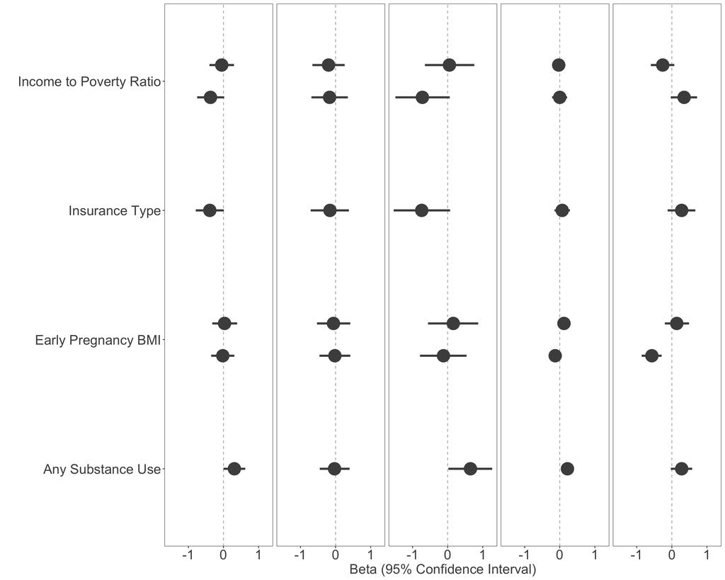

```r
# Create labels
chemical_label <- c("BDE-47", "BDE-99", "BDE-100", "HCP", "p'DDE")
names(chemical_label) <- c("PBDE47", "PBDE99", "PBDE100", "ppDDE")


# Factor

# Add column for grouping
# Format results
results_1 <- results_1 %>%
  mutate(Exposure = rep(c("Income to Poverty Ratio:100-199%" ,"Income to Poverty Ratio: ≥ 200%", "Insurance Type", "Early Pregnancy BMI: Overweight","Early Pregnancy BMI: Obese", "Any Substance Use"), times = 5),group =  rep(c("Income to Poverty Ratio" ,"Income to Poverty Ratio", "Insurance Type", "Early Pregnancy BMI","Early Pregnancy BMI", "Any Substance Use"), times = 5))

results_1$Chemical <- factor(results_1$Chemical, levels = chemical_names1)
results_1$group <- factor(results_1$group, levels = c("Any Substance Use", "Early Pregnancy BMI", "Insurance Type", "Income to Poverty Ratio"))

# Plot
figure_1 <-  ggplot(results_1, aes(x = Beta, y = group, group = Exposure)) +
  geom_pointrange(aes(xmin = conf_low, xmax = conf_high), size = 2, linewidth = 1.5, position=position_dodge(width=0.5), color = "grey30") +
  geom_vline(xintercept = 0, color = "grey30", linetype = "dashed", alpha = 0.5) +
  facet_grid(~Chemical, labeller = labeller(Chemical = chemical_label)) +
  xlab("Beta (95% Confidence Interval)") +
  ylab("") +
  theme_bw() +
  theme(title = element_text(size = 20, color = "grey30"),
        axis.title.x = element_text(size = 20, color = "grey30"),
        axis.title.y = element_text(size = 20, color = "grey30"),
        axis.text.x = element_text(size = 20, color = "grey30"),
        axis.text.y = element_text(size = 20, color = "grey30"),
        strip.background = element_rect(fill="white"),
        strip.text = element_blank(),
        strip.background.x = element_blank(),
        panel.grid = element_blank(),
        legend.title = element_blank(),
        legend.position = "none")

figure_1
```

### Figure 2

Associations between housing characteristics and natural log transformed polybrominated diphenyl esters (PBDEs; pg/mL) and organochlorine pesticides (OCPs; pg/mL) in maternal serum obtained at 8-14 weeks gestation, estimated using adjusted linear regression models, in the Atlanta African American Maternal-Child Cohort.

Regression

```r
#### MODEL 3: Home Exposures
# adjusted for mat_age, mat_educ, ppbmi, unadjusted lipids

exposure_names2 <- c("Apartment", "`Multifamily Home`",  "`Home Age`", "`Couch Age`", "`Once every couple of week or less`",  "`A few times a week`", "Vacuums")

lm.regression.2 <- function(data) {

  results <- data.frame(Chemical = character(0), Beta = numeric(0), conf_low = numeric(0), conf_high = numeric(0))

  for (chemical_name in chemical_names1) {
    for (exposure_name in exposure_names2) {
      formula <- as.formula(paste("log(", chemical_name, ") ~ (", exposure_name, ") + `Maternal Age` + `Maternal Education` + `Maternal BMI`"))
      model <- lm(formula, data = data)
      coef.beta <- round(coef(model)[2], 2)
      conf_intervals <- confint(model)
      conf_low <- round(conf_intervals[2, 1], 2)
      conf_high <- round(conf_intervals[2, 2], 2)

      result <- data.frame(
        Chemical = chemical_name,
        Beta = coef.beta,
        conf_low = conf_low,
        conf_high = conf_high
      )
      results <- bind_rows(results, result)
    }
  }

  return(results)
}

results_2 <- lm.regression.2(final)


#### Diet
exposure_names3 <- c("`Red Meat`", "Milk", "Cheese", "Yogurt")

lm.regression.3 <- function(data) {

  results <- data.frame(Chemical = character(0), Beta = numeric(0), conf_low = numeric(0), conf_high = numeric(0))

  for (chemical_name in chemical_names1) {
    for (exposure_name in exposure_names3) {
      formula <- as.formula(paste("log(", chemical_name, ") ~ (", exposure_name, ") + `Maternal Age` + `Maternal Education` + `Maternal BMI`"))
      model <- lm(formula, data = data)
      coef.beta <- round(coef(model)[2], 2)
      conf_intervals <- confint(model)
      conf_low <- round(conf_intervals[2, 1], 2)
      conf_high <- round(conf_intervals[2, 2], 2)

      result <- data.frame(
        Chemical = chemical_name,
        Beta = coef.beta,
        conf_low = conf_low,
        conf_high = conf_high
      )
      results <- bind_rows(results, result)
    }
  }

  return(results)
}

results_3 <- lm.regression.3(final_adj_diet)

results_2 <- rbind(results_2, results_3)

results_2 <- results_2 %>%
    mutate(Exposure = c(
    rep(c("Home Type: Apartment", "Home Type: Multifamily Home", "Home Age", "Couch Age", "Cleaning Frequency: once every couple of weeks or less", "Cleaning Frequency: a few times a week", "Vacuums Floor"), 5),
    rep(c("Red Meat", "Milk", "Cheese", "Yogurt"), 5)),
    group= c(rep(c("Home Type", "Home Type", "Home Age", "Couch Age", "Cleaning Frequency", "Cleaning Frequency", "Vacuums Floor"), 5),
    rep(c("Diet", "Diet", "Diet", "Diet"), 5)))
```

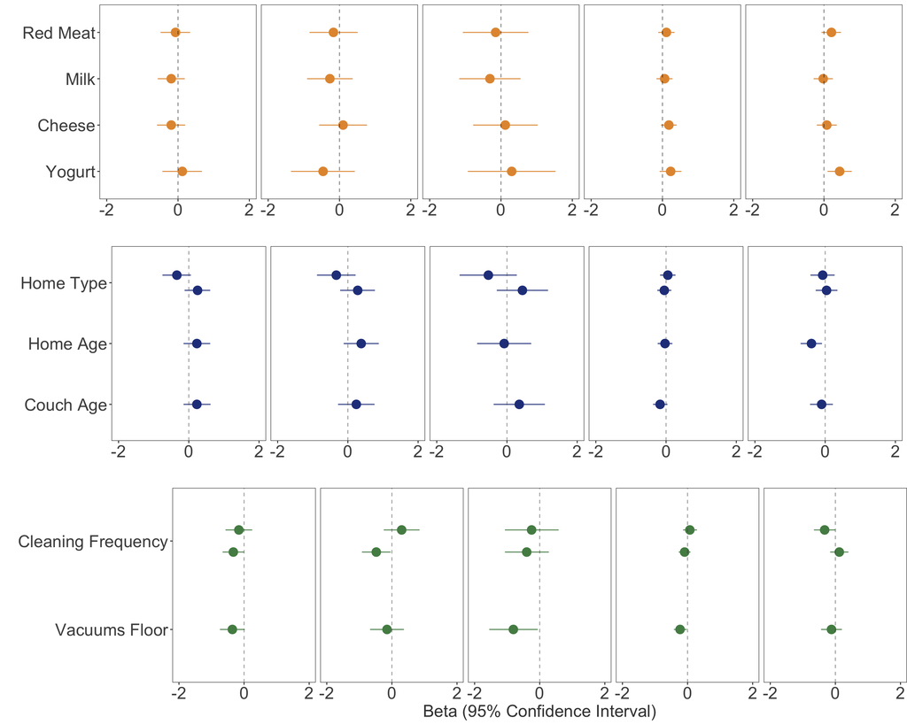

```r
# Factor and subset
diet <- results_2 %>% filter(group == "Diet")

diet$Chemical <- factor(diet$Chemical, levels = chemical_names1)
diet$Exposure <- factor(diet$Exposure, levels = c("Yogurt","Cheese", "Milk", "Red Meat"))

# Plot
diet <- ggplot(diet, aes(x = Beta, color = Exposure, y = Exposure)) +
  geom_pointrange(aes(xmin = conf_low, xmax = conf_high), size = 1) +
  geom_vline(xintercept = 0, color = "black", linetype = "dashed", alpha = 0.5) +
  facet_grid(~Chemical, labeller = labeller(Chemical = chemical_label)) +
  xlab("") +
  ylab("") +
  scale_color_manual(values = c("#E3963E", "#E3963E","#E3963E", "#E3963E")) +
  scale_x_continuous(limits = c(-2, 2), breaks = c(-2,0,2)) +
  theme_bw() +
  theme(title = element_text(size = 20, color = "black"),
        axis.text.y = element_text(size = 20),
        axis.text.x = element_text(size = 20),
        strip.background = element_rect(fill="white"),
        strip.text = element_blank(),
        strip.background.x = element_blank(),
        panel.grid = element_blank(),
        legend.title = element_blank(),
        legend.position = "none")

# Factor and subset
charac <- results_2 %>% filter(Exposure %in% c("Home Type: Apartment", "Home Type: Multifamily Home", "Couch Age", "Home Age"))

charac$Chemical <- factor(charac$Chemical, levels = chemical_names1)
charac$group <- factor(charac$group, levels = c("Couch Age", "Home Age", "Home Type"))

# Plot
charac <- ggplot(charac, aes(x = Beta, y = group, color = group, group = Exposure)) +
  geom_pointrange(aes(xmin = conf_low, xmax = conf_high), size = 1, position=position_dodge(width=0.5)) +
  geom_vline(xintercept = 0, color = "grey25", linetype = "dashed", alpha = 0.5) +
  facet_grid(~Chemical, labeller = labeller(Chemical = chemical_label)) +
  xlab("") +
  ylab("") +
  theme_bw() +
  scale_color_manual(values = c("royalblue4", "royalblue4", "royalblue4", "royalblue4")) +
  scale_x_continuous(limits = c(-2, 2), breaks = c(-2,0,2)) +
  theme(title = element_text(size = 20, color = "grey25"),
        axis.text.y = element_text(size = 20),
        axis.text.x = element_text(size = 20),
        strip.background = element_rect(fill="white"),
        strip.text = element_blank(),
        strip.background.x = element_blank(),
        panel.grid = element_blank(),
        legend.title = element_blank(),
        legend.position = "none")

# Factor and subset
behav <- results_2 %>% filter(Exposure %in% c("Cleaning Frequency: once every couple of weeks or less", "Cleaning Frequency: a few times a week", "Vacuums Floor"))

behav$Chemical <- factor(behav$Chemical, levels = chemical_names1)
behav$group <- factor(behav$group, levels = c("Vacuums Floor", "Cleaning Frequency"))

# Plot
behav <- ggplot(behav, aes(x = Beta, y = group, color = group, group = Exposure)) +
  geom_pointrange(aes(xmin = conf_low, xmax = conf_high), size = 1, position=position_dodge(width=0.5)) +
  geom_vline(xintercept = 0, color = "grey25", linetype = "dashed", alpha = 0.5) +
  facet_grid(~Chemical, labeller = labeller(Chemical = chemical_label)) +
  xlab("Beta (95% Confidence Interval)") +
  ylab("") +
  theme_bw() +
  scale_color_manual(values = c("palegreen4", "palegreen4", "palegreen4")) +
  scale_x_continuous(limits = c(-2, 2), breaks = c(-2,0,2)) +
  theme(title = element_text(size = 20, color = "grey25"),
        axis.text.y = element_text(size = 20),
        axis.text.x = element_text(size = 20),
        strip.background = element_rect(fill="white"),
        strip.text = element_blank(),
        strip.background.x = element_blank(),
        panel.grid = element_blank(),
        legend.title = element_blank(),
        legend.position = "none")


figure_2 <- cowplot::plot_grid(diet,
                   charac,
                   behav + theme(plot.margin = margin(l = 0, unit = "cm")),
                   nrow = 3,
                   align = "h")

figure_2
```

## **Supplemental Tables and Figures**

### Table S1

Distribution of maternal serum polybrominated diphenyl esters (PBDEs; pg/mL) and organochlorine pesticides (OCPs; pg/mL) in the Atlanta African American Maternal-Child Cohort across demographics, home environment, and behavior. Geometric mean and standard deviation.

#### Demographics/Home

```r
# Select variables
demo_names <- c("Maternal Education", "Marital Status", "Income to Poverty Ratio", "Insurance Type", "Prenatal Site", "Parity", "Maternal BMI", "Substance Use", "Home Age", "Home Type", "Couch Age", "Vacuums", "Cleaning Frequency")

chemical_names <- c("PBDE47", "PBDE99", "PBDE100", "HCB", "ppDDE")

table_s1_demo <- final_adj %>%
  dplyr::select(all_of(demo_names), all_of(chemical_names))

table_s1_demo <- table_s1_demo %>%
  pivot_longer(cols = all_of(demo_names), names_to = "demo_var", values_to = "demo_group")

# Get distributions
table_s1_demo <- table_s1_demo %>%
  group_by(demo_var, demo_group) %>%
  drop_na(demo_group) %>%
  summarize(
    bde47_mean = round(exp(mean(log(PBDE47), na.rm = TRUE)), 2),
    bde47_sd = round(exp(sd(log(PBDE47), na.rm = TRUE)), 2),
    bde99_mean = round(exp(mean(log(PBDE99), na.rm = TRUE)), 2),
    bde99_sd = round(exp(sd(log(PBDE99), na.rm = TRUE)), 2),
    bde100_mean = round(exp(mean(log(PBDE100), na.rm = TRUE)), 2),
    bde100_sd = round(exp(sd(log(PBDE100), na.rm = TRUE)), 2),
    hcb_mean = round(exp(mean(log(HCB), na.rm = TRUE)), 2),
    hcb_sd = round(exp(sd(log(HCB), na.rm = TRUE)), 2),
    ppdde_mean = round(exp(mean(log(ppDDE), na.rm = TRUE)), 2),
    ppdde_sd = round(exp(sd(log(ppDDE), na.rm = TRUE)), 2)) %>%
  mutate(
    BDE47 = paste0(bde47_mean, " (", bde47_sd, ")"),
    BDE99 = paste0(bde99_mean, " (", bde99_sd, ")"),
    BDE100 = paste0(bde100_mean, " (", bde100_sd, ")"),
    HCB = paste0(hcb_mean, " (", hcb_sd, ")"),
    ppDDE = paste0(ppdde_mean, " (", ppdde_sd, ")"),
  )


# Format table
table_s1_demo <- table_s1_demo %>%
  dplyr::select(demo_var, demo_group, BDE47, BDE99, BDE100, HCB, ppDDE) %>%
  rename(Demographic = demo_var, Group = demo_group) %>%
  ungroup() %>%
  mutate("Demographic" = c("Cleaning Frequency", "", "",
                           "Couch Age", "",
                     "Home Age", "",
                     "Home Type", "", "",
                     "Income to Poverty Ratio", "", "",
                     "Insurance Type", "",
                     "Marital Status", "",
                     "Maternal BMI", "", "",
                     "Maternal Education", "",
                     "Parity", "",
                     "Prenatal Site", "",
                      "Substance Use", "",
                     "Vacuum", "")) %>%
  regulartable() %>%
  add_header_row(values = c("", "Polybrominated diphenyl esters (PBDEs)", "Organochlorine pesticides (OCPs)"),
                 colwidths = c(2, 3, 2)) %>%
   add_body_row(values = c("", "","Geometric Mean (SD)", "Geometric Mean (SD)", "Geometric Mean (SD)", "Geometric Mean (SD)","Geometric Mean (SD)")) %>%
italic(part = "body", j = "Group") %>%
  set_caption("Table S1: Distribution of maternal serum polybrominated diphenyl esters (PBDEs; ng/g lipid) and organochlorine pesticides (OCPs; ng/g lipid) across demographics in the Atlanta African American Maternal-Child Cohort (N=54)")  %>%
  theme_alafoli %>%
  autofit()



table_s1_demo
```

| Demographic | Group | Polybrominated diphenyl esters (PBDEs) BDE47 | Polybrominated diphenyl esters (PBDEs) BDE99 | Polybrominated diphenyl esters (PBDEs) BDE100 | Organochlorine pesticides (OCPs) HCB | Organochlorine pesticides (OCPs) ppDDE |
| --- | --- | --- | --- | --- | --- | --- |
|  |  | Geometric Mean (SD) | Geometric Mean (SD) | Geometric Mean (SD) | Geometric Mean (SD) | Geometric Mean (SD) |
| Cleaning Frequency | A few times a week | 62.66 (1.69) | 16.65 (1.95) | 7.49 (2.92) | 62.79 (1.32) | 232.86 (1.64) |
|  | <= Once every couple of weeks | 65.4 (1.78) | 27.23 (2.56) | 7.8 (3.23) | 69.28 (1.52) | 167.74 (1.85) |
|  | Daily or more often | 103.34 (1.71) | 25.43 (2.06) | 14.55 (3.36) | 65.06 (1.34) | 182.03 (1.81) |
| Couch Age | < 5 years old | 72.62 (1.91) | 20.83 (2.08) | 8.8 (3.14) | 69.52 (1.44) | 213.12 (1.89) |
|  | > 5 years old | 89.21 (1.67) | 27.03 (2.32) | 13.6 (3.15) | 60.9 (1.24) | 203.03 (1.66) |
| Home Age | < 10 years old | 65.06 (1.81) | 17.72 (2.04) | 10.34 (3.21) | 66.99 (1.3) | 284.99 (1.65) |
|  | > 10 years old | 85.41 (1.75) | 24.88 (2.17) | 10.46 (3.33) | 65.32 (1.41) | 177.8 (1.74) |
| Home Type | Apartment | 87.5 (1.81) | 25.1 (2.52) | 12.22 (3.41) | 61.19 (1.34) | 175.38 (1.89) |
|  | Multi Family Home | 57.64 (1.75) | 16.58 (1.87) | 6.16 (2.48) | 66 (1.37) | 170.31 (1.82) |
|  | Single Family Home | 77.72 (1.75) | 21.62 (2.01) | 9.93 (3.35) | 67.23 (1.39) | 232.95 (1.61) |
| Income to Poverty Ratio | 100% - 199% | 73.45 (1.65) | 18.73 (2.6) | 10.01 (3.16) | 63.7 (1.44) | 165.07 (1.61) |
|  | <100% | 87.53 (1.78) | 24.71 (1.88) | 11.92 (3.33) | 65.71 (1.39) | 198.31 (1.88) |
|  | >200% | 56.74 (1.86) | 18.8 (2.18) | 5.46 (2.7) | 64.71 (1.2) | 262.26 (1.55) |
| Insurance Type | Medicaid | 81.77 (1.73) | 22.19 (2.19) | 11.06 (3.3) | 64.1 (1.38) | 188.86 (1.84) |
|  | Private | 55.36 (1.89) | 18.85 (2.01) | 5.3 (2.37) | 68.57 (1.27) | 249.27 (1.26) |
| Marital Status | Married/Living with a partner | 67.48 (1.78) | 18.7 (1.93) | 7.26 (3.09) | 61.16 (1.28) | 205.95 (1.59) |
|  | Single | 83.15 (1.78) | 23.9 (2.3) | 11.92 (3.22) | 67.84 (1.42) | 193.69 (1.89) |
| Maternal BMI | Obese | 75.05 (1.83) | 21.29 (1.91) | 8.95 (2.81) | 59.65 (1.37) | 138.52 (1.59) |
|  | Overweight | 78 (1.88) | 20.68 (2.87) | 10.8 (3.71) | 70.73 (1.43) | 220.77 (1.97) |
|  | Underweight or normal | 75.67 (1.72) | 22.48 (1.91) | 9.57 (3.45) | 66.29 (1.29) | 267.78 (1.4) |
| Maternal Education | < some college | 80.82 (1.78) | 20.9 (1.99) | 10.25 (3.26) | 65.49 (1.42) | 179.29 (1.82) |
|  | >= College degree | 68.63 (1.8) | 22.63 (2.46) | 8.72 (3.21) | 63.93 (1.25) | 237.03 (1.59) |
| Parity | 1 or more prior births | 77.42 (1.89) | 22.72 (2.33) | 9.96 (3.53) | 64.12 (1.28) | 193.25 (1.83) |
|  | No prior births | 73.66 (1.6) | 19.49 (1.83) | 9.12 (2.73) | 66.38 (1.5) | 209.52 (1.64) |
| Prenatal Site | Emory | 63.96 (1.87) | 21.39 (2.63) | 7.18 (3.04) | 62.42 (1.25) | 222.44 (1.43) |
|  | Grady | 82.39 (1.73) | 21.59 (1.96) | 11.06 (3.26) | 66.09 (1.41) | 188.83 (1.89) |
| Substance Use | No | 66.19 (1.76) | 21.79 (2.23) | 7.24 (3.23) | 58.84 (1.27) | 175.76 (1.67) |
|  | Yes | 90.53 (1.75) | 21.2 (2.09) | 13.83 (2.95) | 73.38 (1.42) | 231.95 (1.83) |
| Vacuum | No | 98.99 (1.72) | 24.13 (1.89) | 16.48 (2.87) | 76.48 (1.55) | 211.9 (1.64) |
|  | Yes | 70.04 (1.78) | 21.13 (2.25) | 8.2 (3.2) | 61.5 (1.26) | 194.41 (1.82) |

#### Diet

```r
#### Diet
demo_names <- c("Red Meat", "Milk", "Cheese", "Yogurt")

chemical_names <- c("PBDE47", "PBDE99", "PBDE100", "HCB", "ppDDE")

table_s1_diet <- final_adj_diet %>%
  dplyr:: select(all_of(demo_names), all_of(chemical_names))

table_s1_diet <- table_s1_diet %>%
  pivot_longer(cols = all_of(demo_names), names_to = "demo_var", values_to = "demo_group")

# Get distributions
table_s1_diet <- table_s1_diet %>%
  group_by(demo_var, demo_group) %>%
  drop_na(demo_group) %>%
  summarize(
    bde47_mean = round(exp(mean(log(PBDE47), na.rm = TRUE)), 2),
    bde47_sd = round(exp(sd(log(PBDE47), na.rm = TRUE)), 2),
    bde99_mean = round(exp(mean(log(PBDE99), na.rm = TRUE)), 2),
    bde99_sd = round(exp(sd(log(PBDE99), na.rm = TRUE)), 2),
    bde100_mean = round(exp(mean(log(PBDE100), na.rm = TRUE)), 2),
    bde100_sd = round(exp(sd(log(PBDE100), na.rm = TRUE)), 2),
    hcb_mean = round(exp(mean(log(HCB), na.rm = TRUE)), 2),
    hcb_sd = round(exp(sd(log(HCB), na.rm = TRUE)), 2),
    ppdde_mean = round(exp(mean(log(ppDDE), na.rm = TRUE)), 2),
    ppdde_sd = round(exp(sd(log(ppDDE), na.rm = TRUE)), 2)) %>%
  mutate(
    BDE47 = paste0(bde47_mean, " (", bde47_sd, ")"),
    BDE99 = paste0(bde99_mean, " (", bde99_sd, ")"),
    BDE100 = paste0(bde100_mean, " (", bde100_sd, ")"),
    HCB = paste0(hcb_mean, " (", hcb_sd, ")"),
    ppDDE = paste0(ppdde_mean, " (", ppdde_sd, ")"),
  )


# Format table
table_s1_diet <- table_s1_diet %>%
  dplyr::select(demo_var, demo_group, BDE47, BDE99, BDE100, HCB, ppDDE) %>%
  rename(Demographic = demo_var, Group = demo_group) %>%
  ungroup() %>%
  mutate(Demographic = c("Cheese", "",
                         "Milk", "",
                         "Red Meat", "",
                         "Yogurt", "")) %>%
   regulartable() %>%
   autofit() %>%
   theme_alafoli() %>%
  add_header_row(values = c("", "Polybrominated diphenyl esters (PBDEs)", "Organochlorine pesticides (OCPs)"),
                 colwidths = c(2,3, 2)) %>%
   add_body_row(values = c("", "","Geometric Mean (SD)", "Geometric Mean (SD)", "Geometric Mean (SD)", "Geometric Mean (SD)","Geometric Mean (SD)")) %>%
   italic(part = "body", j = "Group") %>%
  set_caption("Table S1: Distribution of maternal serum polybrominated diphenyl esters (PBDEs; ng/g lipid) and organochlorine pesticides (OCPs; ng/g lipid) across diet in the Atlanta African American Maternal-Child Cohort (N=54)")


table_s1_diet
```

Table S1: Distribution of maternal serum polybrominated diphenyl esters (PBDEs; ng/g lipid) and organochlorine pesticides (OCPs; ng/g lipid) across diet in the Atlanta African American Maternal-Child Cohort (N=54)

| Demographic | Group | Polybrominated diphenyl esters (PBDEs) BDE47 | Polybrominated diphenyl esters (PBDEs) BDE99 | Polybrominated diphenyl esters (PBDEs) BDE100 | Organochlorine pesticides (OCPs) HCB | Organochlorine pesticides (OCPs) ppDDE |
| --- | --- | --- | --- | --- | --- | --- |
|  |  | Geometric Mean (SD) | Geometric Mean (SD) | Geometric Mean (SD) | Geometric Mean (SD) | Geometric Mean (SD) |
| Cheese | < Once a week | 81.68 (1.63) | 19.89 (1.85) | 9.7 (3.38) | 59.44 (1.24) | 177.82 (1.65) |
|  | >= Once a week | 61.86 (1.68) | 20.56 (2.55) | 7.79 (3.16) | 67.84 (1.46) | 205.61 (1.65) |
| Milk | < Once a week | 77.91 (1.83) | 22.51 (2.52) | 10.23 (3.57) | 63.6 (1.19) | 191.84 (1.35) |
|  | >= Once a week | 62.97 (1.46) | 17.77 (1.8) | 7.08 (2.83) | 63.68 (1.54) | 191.44 (1.97) |
| Red Meat | < 2-3 times per month | 71.9 (1.67) | 22.46 (1.82) | 8.89 (3.33) | 59.15 (1.33) | 173.57 (1.8) |
|  | >= 2-3 times per month | 71.47 (1.73) | 19.24 (2.58) | 9.02 (3.28) | 69.25 (1.4) | 211.35 (1.5) |
| Yogurt | < Once a week | 71.19 (1.71) | 21.55 (2.22) | 8.77 (3.23) | 62.73 (1.38) | 178.39 (1.59) |
|  | >= Once a week | 68.58 (1.56) | 14.58 (2.04) | 8.1 (3.59) | 68.57 (1.33) | 278.35 (1.72) |

### Table S2

Associations between sociodemographic characteristics and natural log transformed polybrominated diphenyl esters (PBDEs; pg/mL) and organochlorine pesticides (OCPs; pg/mL) in maternal serum, estimated using unadjusted linear regression models.

```r
# Format
table_s2 <- results_1 %>%
  mutate(Beta_CI = paste0(Beta, " (", conf_low, ", ", conf_high, ")")) %>%
  select(Exposure, Chemical, Beta_CI) %>%
  pivot_wider(names_from = Chemical, values_from = Beta_CI) %>%
  rename("BDE-47" = PBDE47,
         "BDE-99" = PBDE99,
         "BDE-100" = PBDE100,
         "p,p'DDE" = ppDDE)

# Table
table_s2 <- table_s2 %>% regulartable() %>%
  add_header_row(values = c("Polybrominated diphenyl esters (PBDEs)", "Organochlorine pesticides (OCPs)"),
                 colwidths = c(4, 2)) %>%
  theme_alafoli() %>%
  align(align = "right", part = "header") %>%
  add_body_row(values = c("", "","Beta (95% CI)", "Beta (95% CI)", "Beta (95% CI)", "Beta (95% CI)", "Beta (95% CI)")) %>%
  autofit() %>%
  set_caption("Table S2: Associations between sociodemographic characteristics and natural log transformed polybrominated diphenyl esters (PBDEs; pg/mL) and organochlorine pesticides (OCPs; ng/mL) in maternal serum, estimated using unadjusted linear regression models")


table_s2
```

Table S2: Associations between sociodemographic characteristics and natural log transformed polybrominated diphenyl esters (PBDEs; pg/mL) and organochlorine pesticides (OCPs; ng/mL) in maternal serum, estimated using unadjusted linear regression models

| Polybrominated diphenyl esters (PBDEs) Exposure | Polybrominated diphenyl esters (PBDEs) BDE-47 | Polybrominated diphenyl esters (PBDEs) BDE-99 | Polybrominated diphenyl esters (PBDEs) BDE-100 | Organochlorine pesticides (OCPs) HCB | Organochlorine pesticides (OCPs) p,p'DDE |
| --- | --- | --- | --- | --- | --- |
|  |  | Beta (95% CI) | Beta (95% CI) | Beta (95% CI) | Beta (95% CI) |
| Income to Poverty Ratio:100-199% | -0.05 (-0.4, 0.3) | -0.2 (-0.66, 0.26) | 0.05 (-0.65, 0.76) | -0.03 (-0.21, 0.16) | -0.26 (-0.6, 0.07) |
| Income to Poverty Ratio: ≥ 200% | -0.37 (-0.75, 0.02) | -0.17 (-0.69, 0.35) | -0.72 (-1.49, 0.06) | 0 (-0.22, 0.21) | 0.35 (-0.03, 0.72) |
| Insurance Type | -0.39 (-0.79, 0.01) | -0.16 (-0.71, 0.38) | -0.74 (-1.54, 0.07) | 0.07 (-0.15, 0.29) | 0.28 (-0.12, 0.67) |
| Early Pregnancy BMI: Overweight | 0.03 (-0.32, 0.39) | -0.06 (-0.53, 0.42) | 0.16 (-0.56, 0.87) | 0.12 (-0.07, 0.31) | 0.14 (-0.2, 0.49) |
| Early Pregnancy BMI: Obese | -0.02 (-0.35, 0.31) | -0.02 (-0.46, 0.42) | -0.12 (-0.79, 0.54) | -0.13 (-0.31, 0.04) | -0.57 (-0.86, -0.29) |
| Any Substance Use | 0.31 (0, 0.62) | -0.03 (-0.45, 0.4) | 0.65 (0.02, 1.27) | 0.22 (0.06, 0.38) | 0.28 (-0.03, 0.58) |

### Table S3

Associations between sociodemographic characteristics and natural log transformed, lipid adjusted polybrominated diphenyl esters (PBDEs; ng/g lipid) and organochlorine pesticides (OCPs; ng/g lipid) in maternal serum, estimated using unadjusted linear regression models.

```r
#### MODEL 2: Demographic Exposures
# unadjusted, adjusted lipids
exposure_names1 <- c("`Maternal Age`", "`Maternal Education`", "`Marital Status`", "Income2", "Income3", "`Insurance Type`","`Prenatal Site`", "Parity", "Overweight", "Obese", "`Substance Use`")
chemical_names2 <- c("la_PBDE47","la_PBDE99", "la_PBDE100", "la_HCB", "la_ppDDE")

lm.regression.11 <- function(data) {

  results <- data.frame(Chemical = character(0), Beta = numeric(0), conf_low = numeric(0), conf_high = numeric(0))

  for (chemical_name in chemical_names2) {
    for (exposure_name in exposure_names1) {
      formula <- as.formula(paste("log(", chemical_name, ") ~ (", exposure_name, ")"))
      model <- lm(formula, data = data)
      coef.beta <- round(coef(model)[2], 2)
      conf_intervals <- confint(model)
      conf_low <- round(conf_intervals[2, 1], 2)
      conf_high <- round(conf_intervals[2, 2], 2)

      result <- data.frame(
        Exposure = exposure_name,
        Chemical = chemical_name,
        Beta = coef.beta,
        conf_low = conf_low,
        conf_high = conf_high,
        N = nobs(model)
      )
      results <- bind_rows(results, result)
    }
  }

  return(results)
}

results_11 <- lm.regression.11(final_adj)
results_11 <- results_11 %>%
  mutate(Exposure = rep(c("Maternal Age", "Maternal Education", "Marital Status", "Income to Poverty Ratio:100-199%" ,"Income to Poverty Ratio: ≥ 200%", "Insurance Type", "Prenatal Site", "Parity", "Early Pregnancy BMI: Overweight","Early Pregnancy BMI: Obese", "Any Substance Use"), times = 5))

table_s3 <- results_11 %>%
  mutate(Beta_CI = paste0(Beta, " (", conf_low, ", ", conf_high, ")")) %>%
  select(Exposure, Chemical, Beta_CI) %>%
  pivot_wider(names_from = Chemical, values_from = Beta_CI) %>%
  rename("BDE-47" = la_PBDE47,
         "BDE-99" = la_PBDE99,
         "BDE-100" = la_PBDE100,
         "HCB" = la_HCB,
         "p,p'DDE" = la_ppDDE)

table_s3 <- table_s3 %>% regulartable() %>%
  add_header_row(values = c("Polybrominated diphenyl esters (PBDEs)", "Organochlorine pesticides (OCPs)"),
                 colwidths = c(4, 2)) %>%
  theme_alafoli() %>%
  align(align = "right", part = "header") %>%
  add_body_row(values = c("", "","Beta (95% CI)", "Beta (95% CI)", "Beta (95% CI)", "Beta (95% CI)", "Beta (95% CI)")) %>%
  autofit() %>%
  set_caption("Table S3: Associations between sociodemographic characteristics and natural log transformed, lipid adjusted polybrominated diphenyl esters (PBDEs; pg/g lipid) and organochlorine pesticides (OCPs; ng/g lipid) in maternal serum, estimated using unadjusted linear regression models")

table_s3
```

Table S3: Associations between sociodemographic characteristics and natural log transformed, lipid adjusted polybrominated diphenyl esters (PBDEs; pg/g lipid) and organochlorine pesticides (OCPs; ng/g lipid) in maternal serum, estimated using unadjusted linear regression models

| Polybrominated diphenyl esters (PBDEs) Exposure | Polybrominated diphenyl esters (PBDEs) BDE-47 | Polybrominated diphenyl esters (PBDEs) BDE-99 | Polybrominated diphenyl esters (PBDEs) BDE-100 | Organochlorine pesticides (OCPs) HCB | Organochlorine pesticides (OCPs) p,p'DDE |
| --- | --- | --- | --- | --- | --- |
|  |  | Beta (95% CI) | Beta (95% CI) | Beta (95% CI) | Beta (95% CI) |
| Maternal Age | -0.03 (-0.07, 0.01) | -0.02 (-0.06, 0.03) | -0.06 (-0.13, 0.01) | 0 (-0.02, 0.02) | 0.03 (-0.01, 0.06) |
| Maternal Education | -0.21 (-0.56, 0.13) | 0.03 (-0.4, 0.46) | -0.21 (-0.87, 0.45) | -0.07 (-0.26, 0.11) | 0.23 (-0.09, 0.55) |
| Marital Status | 0.22 (-0.12, 0.55) | 0.25 (-0.16, 0.67) | 0.5 (-0.13, 1.14) | 0.11 (-0.07, 0.29) | -0.05 (-0.37, 0.26) |
| Income to Poverty Ratio:100-199% | -0.08 (-0.44, 0.29) | -0.22 (-0.67, 0.23) | 0.02 (-0.68, 0.73) | -0.05 (-0.25, 0.14) | -0.29 (-0.62, 0.04) |
| Income to Poverty Ratio: ≥ 200% | -0.4 (-0.8, 0.01) | -0.2 (-0.71, 0.31) | -0.74 (-1.51, 0.02) | -0.03 (-0.25, 0.19) | 0.32 (-0.06, 0.7) |
| Insurance Type | -0.44 (-0.85, -0.03) | -0.21 (-0.74, 0.32) | -0.79 (-1.58, 0.01) | 0.02 (-0.21, 0.25) | 0.23 (-0.17, 0.63) |
| Prenatal Site | -0.34 (-0.69, 0.01) | -0.1 (-0.54, 0.35) | -0.52 (-1.19, 0.15) | -0.15 (-0.33, 0.04) | 0.08 (-0.26, 0.41) |
| Parity | -0.04 (-0.39, 0.31) | 0.06 (-0.37, 0.5) | 0 (-0.67, 0.67) | -0.12 (-0.31, 0.06) | -0.17 (-0.49, 0.15) |
| Early Pregnancy BMI: Overweight | -0.08 (-0.45, 0.29) | -0.17 (-0.63, 0.29) | 0.04 (-0.67, 0.76) | 0.01 (-0.19, 0.21) | 0.03 (-0.32, 0.38) |
| Early Pregnancy BMI: Obese | 0.03 (-0.31, 0.38) | 0.04 (-0.39, 0.47) | -0.07 (-0.73, 0.6) | -0.08 (-0.26, 0.11) | -0.52 (-0.81, -0.23) |
| Any Substance Use | 0.3 (-0.03, 0.62) | -0.04 (-0.46, 0.37) | 0.63 (0.01, 1.25) | 0.21 (0.04, 0.38) | 0.26 (-0.04, 0.57) |

### Table S4

Associations between housing characteristics and natural log transformed polybrominated diphenyl esters (PBDEs; pg/mL) and organochlorine pesticides (OCPs; pg/mL) in maternal serum, estimated using adjusted linear regression models. Models are adjusted for maternal age, maternal education, and early pregnancy body mass index.

```r
table_s4 <- results_2 %>%
  mutate(Beta_CI = paste0(Beta, " (", conf_low, ", ", conf_high, ")")) %>%
  dplyr::select(group, Exposure, Chemical, Beta_CI) %>%
   pivot_wider(names_from = Chemical, values_from = Beta_CI) %>%
  regulartable() %>%
  add_header_row(values = c("Polybrominated diphenyl esters (PBDEs)", "Organochlorine pesticides (OCPs)"),
                 colwidths = c(5, 2)) %>%
  theme_alafoli() %>%
  align(align = "right", part = "header") %>%
  add_body_row(values = c("", "","Beta (95% CI)", "Beta (95% CI)", "Beta (95% CI)", "Beta (95% CI)", "Beta (95% CI)")) %>%
  autofit() %>%
  set_caption("Table S4: Associations between housing characteristics and natural log transformed polybrominated diphenyl esters (PBDEs; pg/mL) and organochlorine pesticides (OCPs; ng/mL) in maternal serum, estimated using adjusted linear regression models. Models are adjusted for maternal age, maternal education, and pre-pregnancy body mass index")

table_s4
```

Table S4: Associations between housing characteristics and natural log transformed polybrominated diphenyl esters (PBDEs; pg/mL) and organochlorine pesticides (OCPs; ng/mL) in maternal serum, estimated using adjusted linear regression models. Models are adjusted for maternal age, maternal education, and pre-pregnancy body mass index

| Polybrominated diphenyl esters (PBDEs) group | Polybrominated diphenyl esters (PBDEs) Exposure | Polybrominated diphenyl esters (PBDEs) PBDE47 | Polybrominated diphenyl esters (PBDEs) PBDE99 | Polybrominated diphenyl esters (PBDEs) PBDE100 | Organochlorine pesticides (OCPs) HCB | Organochlorine pesticides (OCPs) ppDDE |
| --- | --- | --- | --- | --- | --- | --- |
|  |  | Beta (95% CI) | Beta (95% CI) | Beta (95% CI) | Beta (95% CI) | Beta (95% CI) |
| Home Type | Home Type: Apartment | 0.25 (-0.12, 0.61) | 0.28 (-0.22, 0.77) | 0.44 (-0.29, 1.17) | -0.05 (-0.25, 0.15) | 0.04 (-0.27, 0.35) |
| Home Type | Home Type: Multifamily Home | -0.34 (-0.75, 0.06) | -0.33 (-0.88, 0.22) | -0.53 (-1.35, 0.28) | 0.05 (-0.17, 0.27) | -0.07 (-0.42, 0.27) |
| Home Age | Home Age | 0.23 (-0.15, 0.61) | 0.38 (-0.12, 0.88) | -0.08 (-0.85, 0.69) | -0.03 (-0.24, 0.18) | -0.39 (-0.7, -0.09) |
| Couch Age | Couch Age | 0.23 (-0.15, 0.62) | 0.24 (-0.28, 0.76) | 0.35 (-0.38, 1.08) | -0.17 (-0.37, 0.04) | -0.1 (-0.43, 0.22) |
| Cleaning Frequency | Cleaning Frequency: once every couple of weeks or less | -0.16 (-0.57, 0.25) | 0.3 (-0.25, 0.85) | -0.25 (-1.07, 0.58) | 0.07 (-0.14, 0.29) | -0.33 (-0.66, 0) |
| Cleaning Frequency | Cleaning Frequency: a few times a week | -0.33 (-0.66, 0) | -0.48 (-0.92, -0.04) | -0.4 (-1.07, 0.28) | -0.09 (-0.27, 0.09) | 0.12 (-0.16, 0.4) |
| Vacuums Floor | Vacuums Floor | -0.36 (-0.74, 0.02) | -0.15 (-0.67, 0.37) | -0.81 (-1.55, -0.06) | -0.23 (-0.42, -0.03) | -0.12 (-0.44, 0.2) |
| Diet | Red Meat | -0.07 (-0.49, 0.34) | -0.17 (-0.84, 0.51) | -0.15 (-1.07, 0.77) | 0.11 (-0.12, 0.34) | 0.21 (-0.07, 0.48) |
| Diet | Milk | -0.19 (-0.57, 0.19) | -0.27 (-0.91, 0.37) | -0.31 (-1.17, 0.55) | 0.06 (-0.17, 0.28) | -0.02 (-0.29, 0.25) |
| Diet | Cheese | -0.19 (-0.59, 0.2) | 0.1 (-0.57, 0.77) | 0.12 (-0.78, 1.03) | 0.18 (-0.04, 0.4) | 0.08 (-0.2, 0.36) |
| Diet | Yogurt | 0.12 (-0.44, 0.67) | -0.46 (-1.36, 0.43) | 0.3 (-0.93, 1.53) | 0.23 (-0.08, 0.53) | 0.44 (0.1, 0.78) |

### Table S5

Associations between housing characteristics and natural log transformed, lipid adjusted polybrominated diphenyl esters (PBDEs; ng/g lipid) and organochlorine pesticides (OCPs; ng/g lipid) in maternal serum, estimated using adjusted linear regression models. Models are adjusted for maternal age, maternal education, and early pregnancy body mass index.

```r
#### MODEL 4: Home Exposures
# adjusted for mat_age, mat_educ, ppbmi, adjusted lipids

lm.regression.22 <- function(data) {

  results <- data.frame(Chemical = character(0), Beta = numeric(0), conf_low = numeric(0), conf_high = numeric(0))

  for (chemical_name in chemical_names2) {
    for (exposure_name in exposure_names2) {
      formula <- as.formula(paste("log(", chemical_name, ") ~ (", exposure_name, ") + `Maternal Age` + `Maternal Education` + `Maternal BMI`"))
      model <- lm(formula, data = data)
      coef.beta <- round(coef(model)[2], 2)
      conf_intervals <- confint(model)
      conf_low <- round(conf_intervals[2, 1], 2)
      conf_high <- round(conf_intervals[2, 2], 2)

      result <- data.frame(
        Exposure = exposure_name,
        Chemical = chemical_name,
        Beta = coef.beta,
        conf_low = conf_low,
        conf_high = conf_high
      )
      results <- bind_rows(results, result)
    }
  }

  return(results)
}

results_22 <- lm.regression.22(final_adj)
results_22 <- results_22 %>%
  mutate(Exposure = rep(c("Cleaning Frequency", "Cleaning Frequency", "Couch Age", "Home Age" , "Home Type", "Home Type", "Vacuums Floor"), times = 5))

#### MODEL : Diet
# adjusted for mat_age, mat_educ, ppbmi, adjusted lipids

lm.regression.33 <- function(data) {

  results <- data.frame(Chemical = character(0), Beta = numeric(0), conf_low = numeric(0), conf_high = numeric(0))

  for (chemical_name in chemical_names2) {
    for (exposure_name in exposure_names3) {
      formula <- as.formula(paste("log(", chemical_name, ") ~ (", exposure_name, ") + `Maternal Age` + `Maternal Education` + `Maternal BMI`"))
      model <- lm(formula, data = data)
      coef.beta <- round(coef(model)[2], 2)
      conf_intervals <- confint(model)
      conf_low <- round(conf_intervals[2, 1], 2)
      conf_high <- round(conf_intervals[2, 2], 2)

      result <- data.frame(
        Exposure = exposure_name,
        Chemical = chemical_name,
        Beta = coef.beta,
        conf_low = conf_low,
        conf_high = conf_high
      )
      results <- bind_rows(results, result)
    }
  }

  return(results)
}

results_33 <- lm.regression.33(final_adj_diet)

table_s5 <- rbind(results_22, results_33)

table_s5 <- table_s5 %>%
    mutate(Exposure = c(
    rep(c("Home Type: Apartment", "Home Type: Multifamily Home", "Home Age", "Couch Age", "Cleaning Frequency: once every couple of weeks or less", "Cleaning Frequency: a few times a week", "Vacuums Floor"), 5),
    rep(c("Red Meat", "Milk", "Cheese", "Yogurt"), 5)), Beta_CI = paste0(Beta, " (", conf_low, ", ", conf_high, ")")) %>%
   select(Exposure, Chemical, Beta_CI) %>%
   pivot_wider(names_from = Chemical, values_from = Beta_CI) %>%
  rename("BDE-47" = la_PBDE47,
         "BDE-99" = la_PBDE99,
         "BDE-100" = la_PBDE100,
         "HCB" = la_HCB,
         "p,p'DDE" = la_ppDDE)

table_s5 <- table_s5 %>%
  regulartable() %>%
  add_header_row(values = c("Polybrominated diphenyl esters (PBDEs)", "Organochlorine pesticides (OCPs)"),
                 colwidths = c(4, 2)) %>%
  add_body_row(values = c("", "","Beta (95% CI)", "Beta (95% CI)", "Beta (95% CI)", "Beta (95% CI)", "Beta (95% CI)")) %>%
  theme_alafoli() %>%
  align(align = "right", part = "header") %>%
  autofit() %>%
  set_caption("Table S5: Associations between housing characteristics and natural log transformed, lipid adjusted polybrominated diphenyl esters (PBDEs; pg/g lipid) and organochlorine pesticides (OCPs; ng/g lipid) in maternal serum, estimated using adjusted linear regression models. Models are adjusted for maternal age, maternal education, and pre-pregnancy body mass index")
table_s5
```

Table S5: Associations between housing characteristics and natural log transformed, lipid adjusted polybrominated diphenyl esters (PBDEs; pg/g lipid) and organochlorine pesticides (OCPs; ng/g lipid) in maternal serum, estimated using adjusted linear regression models. Models are adjusted for maternal age, maternal education, and pre-pregnancy body mass index

| Polybrominated diphenyl esters (PBDEs) Exposure | Polybrominated diphenyl esters (PBDEs) BDE-47 | Polybrominated diphenyl esters (PBDEs) BDE-99 | Polybrominated diphenyl esters (PBDEs) BDE-100 | Organochlorine pesticides (OCPs) HCB | Organochlorine pesticides (OCPs) p,p'DDE |
| --- | --- | --- | --- | --- | --- |
|  |  | Beta (95% CI) | Beta (95% CI) | Beta (95% CI) | Beta (95% CI) |
| Home Type: Apartment | 0.27 (-0.1, 0.65) | 0.3 (-0.18, 0.78) | 0.46 (-0.26, 1.19) | -0.03 (-0.24, 0.18) | 0.06 (-0.25, 0.38) |
| Home Type: Multifamily Home | -0.39 (-0.81, 0.02) | -0.38 (-0.91, 0.16) | -0.58 (-1.38, 0.23) | 0 (-0.23, 0.23) | -0.12 (-0.47, 0.23) |
| Home Age | 0.3 (-0.09, 0.7) | 0.46 (-0.03, 0.94) | -0.01 (-0.77, 0.76) | 0.04 (-0.18, 0.27) | -0.32 (-0.64, 0) |
| Couch Age | 0.26 (-0.14, 0.66) | 0.27 (-0.24, 0.78) | 0.38 (-0.35, 1.11) | -0.14 (-0.35, 0.08) | -0.07 (-0.41, 0.26) |
| Cleaning Frequency: once every couple of weeks or less | -0.22 (-0.64, 0.21) | 0.24 (-0.3, 0.78) | -0.31 (-1.12, 0.51) | 0.02 (-0.22, 0.25) | -0.38 (-0.72, -0.05) |
| Cleaning Frequency: a few times a week | -0.34 (-0.68, 0) | -0.5 (-0.93, -0.08) | -0.42 (-1.09, 0.25) | -0.11 (-0.3, 0.08) | 0.11 (-0.19, 0.4) |
| Vacuums Floor | -0.39 (-0.78, -0.01) | -0.18 (-0.69, 0.32) | -0.84 (-1.57, -0.11) | -0.26 (-0.46, -0.05) | -0.15 (-0.48, 0.18) |
| Red Meat | -0.09 (-0.52, 0.34) | -0.18 (-0.82, 0.46) | -0.16 (-1.08, 0.75) | 0.09 (-0.18, 0.37) | 0.19 (-0.1, 0.49) |
| Milk | -0.11 (-0.52, 0.29) | -0.19 (-0.8, 0.42) | -0.23 (-1.09, 0.63) | 0.14 (-0.12, 0.39) | 0.06 (-0.23, 0.36) |
| Cheese | -0.3 (-0.7, 0.11) | 0 (-0.64, 0.64) | 0.02 (-0.88, 0.92) | 0.08 (-0.19, 0.34) | -0.02 (-0.33, 0.28) |
| Yogurt | 0.18 (-0.39, 0.76) | -0.4 (-1.26, 0.47) | 0.37 (-0.85, 1.59) | 0.29 (-0.05, 0.64) | 0.51 (0.15, 0.87) |

### Figure S1

```r
# Create dataset with log adjusted and unadjusted PBDE exposures
chemicals <- final_adj %>% select(subjectid, PBDE47, PBDE99, PBDE100, HCB, ppDDE) %>%
  mutate(across(c(PBDE47, PBDE99, PBDE100, HCB, ppDDE), log))

# Correlation matrix
chemicals_cor <- chemicals %>% select(PBDE47, PBDE99, PBDE100, HCB, ppDDE) %>%
  rename("BDE-47" = PBDE47,
         "BDE-99" = PBDE99,
         "BDE-100" = PBDE100,
          "p,p'-DDE" = ppDDE)

corr_chemicals <- cor(chemicals_cor)

# Correlation plot
pdf("FIGURES2.pdf")
corrplot(corr_chemicals, method = "shade", outline = T, tl.col = "black", addgrid.col = 'white',number.cex = 0.75) %>%
corrRect(c(1, 4, 5))
dev.off()
```